# Mini-Project 2

Leigh Tanji & Samantha Bryce

October 31, 2017

## Loading the data

```r
library(dplyr)
library(ggplot2)
```

```r
tbl_df(house_elections)
```

```
## # A tibble: 2,178 x 10
##       fec_id state district incumbent   candidate_name party primary_votes
##        <chr> <chr>    <chr>     <chr>            <chr> <chr>         <int>
##  1 B2CA08156    CA       08     FALSE Mitzelfelt, Brad     R          8801
##  2 H0AK00097    AK       00     FALSE     Cox, John R.     R         11179
##  3 H0AL01030    AL       01     FALSE  Gounares, Peter     R          3854
##  4 H0AL02087    AL       02      TRUE     Roby, Martha     R             0
##  5 H0AL05163    AL       05      TRUE       Brooks, Mo     R         65163
##  6 H0AL07086    AL       07      TRUE Sewell, Terri A.     D             0
##  7 H0AL07177    AL       07     FALSE Chamberlain, Don     R         11537
##  8 H0AR01083    AR       01      TRUE  Crawford, Rick      R             0
##  9 H0AR02107    AR       02      TRUE    Griffin, Tim      R             0
## 10 H0AR03055    AR       03      TRUE    Womack, Steve     R             0
## # ... with 2,168 more rows, and 3 more variables: runoff_votes <int>,
## #   general_votes <int>, ge_winner <chr>
```

# How many incumbents won their elections?

Saving this information for both parties as a dataframe.

```r
parties <- c("D", "R")

win_incumbs<- function(party_arg) {
house_elections %>%
  filter(incumbent == "TRUE" & party == party_arg) %>%
  group_by(state) %>%
  summarise(winners = sum(ge_winner == "W"))
}

wins <- lapply(parties, win_incumbs)

names(wins) <- c("win_dem", "win_rep")
list2env(wins, envir = .GlobalEnv)
```

```
## <environment: R_GlobalEnv>
```

# How many candidates were running for each party?

```r
total_candidates <- function(party_arg) {
  house_elections %>%
  filter(party == party_arg) %>%
  group_by(state) %>%
  summarise(N = n()) %>%
  data.frame()
}

total <- lapply(parties, total_candidates)

names(total) <- c("total_dem", "total_rep")
list2env(total, envir = .GlobalEnv)
```

```
## <environment: R_GlobalEnv>
```

```r
tbl_df(total_dem)
```

```
## # A tibble: 54 x 2
##    state     N
##    <chr> <int>
##  1    AK     5
##  2    AL     8
##  3    AR     8
##  4    AS     2
##  5    AZ    18
##  6    CA   105
##  7    CO     6
##  8    CT     4
##  9    DC     2
## 10    DE     1
## # ... with 44 more rows
```

```r
tbl_df(total_rep)
```

```
## # A tibble: 53 x 2
##    state     N
##    <chr> <int>
##  1    AK     3
##  2    AL    15
##  3    AR     6
##  4    AZ    24
##  5    CA    97
##  6    CO    10
##  7    CT    17
##  8    DE     2
##  9    FL    53
## 10    GA    28
## # ... with 43 more rows
```

Checking the ‘total_incumbs’ numbers from ‘incumbs’. Should be 794 and 925.

```r
total1 <- total_dem %>%
  summarise(SUM = sum(N))
total1
```

```
##   SUM
## 1 794
```

```r
total2 <- total_rep %>%
  summarise(SUM = sum(N))
total2
```

```
##   SUM
## 1 925
```

```r
total3 <- function(party_arg) {
  house_elections %>%
  filter(party == party_arg) %>%
  group_by(state) %>%
  select(state, party)
}

lapply(parties, total3)
```

```
## [[1]]
## # A tibble: 794 x 2
## # Groups:   state [54]
##    state party
##    <chr> <chr>
##  1    AL     D
##  2    AS     D
##  3    AZ     D
##  4    CA     D
##  5    CA     D
##  6    CA     D
##  7    CA     D
##  8    CA     D
##  9    CA     D
## 10    CA     D
## # ... with 784 more rows
##
## [[2]]
## # A tibble: 925 x 2
## # Groups:   state [53]
##    state party
##    <chr> <chr>
##  1    CA     R
##  2    AK     R
##  3    AL     R
##  4    AL     R
##  5    AL     R
##  6    AL     R
##  7    AR     R
##  8    AR     R
##  9    AR     R
## 10    AR     R
## # ... with 915 more rows
```

Checking the ‘winners_incumb’ numbers from ‘incumbs’. Should be 152 and 199.

```r
winners_incumbs1 <- win_dem %>%
  summarise(SUM= sum(winners))
winners_incumbs1
```

```
## # A tibble: 1 x 1
##     SUM
##   <int>
## 1   152
```

```r
winners_incumbs2 <- win_rep %>%
  summarise(SUM = sum(winners))
winners_incumbs2
```

```
## # A tibble: 1 x 1
##     SUM
##   <int>
## 1   199
```

```r
winners_incumbs3 <- function(party_arg) {
  house_elections %>%
  filter(incumbent == "TRUE" &  party == party_arg & ge_winner == "W") %>%
  group_by(state) %>%
  select(state, incumbent, ge_winner, party)
}

lapply(parties, winners_incumbs3)
```

```
## [[1]]
## # A tibble: 152 x 4
## # Groups:   state [41]
##    state incumbent ge_winner party
##    <chr>     <chr>     <chr> <chr>
##  1    AL      TRUE         W     D
##  2    AS      TRUE         W     D
##  3    CA      TRUE         W     D
##  4    CA      TRUE         W     D
##  5    CA      TRUE         W     D
##  6    CA      TRUE         W     D
##  7    CA      TRUE         W     D
##  8    CA      TRUE         W     D
##  9    DC      TRUE         W     D
## 10    DE      TRUE         W     D
## # ... with 142 more rows
##
## [[2]]
## # A tibble: 199 x 4
## # Groups:   state [40]
##    state incumbent ge_winner party
##    <chr>     <chr>     <chr> <chr>
##  1    AL      TRUE         W     R
##  2    AL      TRUE         W     R
##  3    AR      TRUE         W     R
##  4    AR      TRUE         W     R
##  5    AR      TRUE         W     R
##  6    AZ      TRUE         W     R
##  7    CA      TRUE         W     R
##  8    CA      TRUE         W     R
##  9    CO      TRUE         W     R
## 10    FL      TRUE         W     R
## # ... with 189 more rows
```

# Percentage of winners.

Calculating percentage of incumbent democratic winners to total democratic candidates.

```r
percentage_dem <- total_dem %>%
  left_join(win_dem, by = "state") %>%
  mutate(percentage = winners*100/N) %>%
  select(state, percentage)

percentage_dem[is.na(percentage_dem)] <- 0

percentage_dem
```

```
##    state percentage
## 1     AK   0.000000
## 2     AL  12.500000
## 3     AR   0.000000
## 4     AS  50.000000
## 5     AZ  16.666667
## 6     CA  25.714286
## 7     CO  50.000000
## 8     CT   0.000000
## 9     DC  50.000000
## 10    DE 100.000000
## 11    FL  16.666667
## 12    GA  31.250000
## 13    GU  50.000000
## 14    HI  12.500000
```

[output cut: 40 more lines]

Calculating percentage of incumbent republican winners to total republican candidates

```r
percentage_rep <- total_rep %>%
  left_join(win_rep, by = "state") %>%
  mutate(percentage = winners*100/N) %>%
  select(state, percentage)

percentage_rep[is.na(percentage_rep)] <- 0

percentage_rep
```

```
##    state percentage
## 1     AK  33.333333
## 2     AL  40.000000
## 3     AR  50.000000
## 4     AZ  12.500000
## 5     CA  12.371134
## 6     CO  40.000000
## 7     CT   0.000000
## 8     DE   0.000000
## 9     FL  26.415094
## 10    GA  28.571429
## 11    GU   0.000000
## 12    HI   0.000000
## 13    IA  33.333333
## 14    ID  50.000000
```

[output cut: 39 more lines]

Combining republican percentage data to democratic data by state.

```r
percentage_parties <- percentage_dem %>%
  inner_join(percentage_rep, by = "state") %>%
  rename(Dem = percentage.x,
       Rep = percentage.y) %>%
  select(state, Dem, Rep)

list2env(percentage_parties, envir = .GlobalEnv)
```

```
## <environment: R_GlobalEnv>
```

```r
percentage_parties
```

```
##    state        Dem        Rep
## 1     AK   0.000000  33.333333
## 2     AL  12.500000  40.000000
## 3     AR   0.000000  50.000000
## 4     AZ  16.666667  12.500000
## 5     CA  25.714286  12.371134
## 6     CO  50.000000  40.000000
## 7     CT   0.000000   0.000000
## 8     DE 100.000000   0.000000
## 9     FL  16.666667  26.415094
## 10    GA  31.250000  28.571429
## 11    GU  50.000000   0.000000
## 12    HI  12.500000   0.000000
## 13    IA  40.000000  33.333333
## 14    ID   0.000000  50.000000
```

[output cut: 38 more lines]

**Incumbent Candidates by Party: Why does the candidate I hate keep getting reelected?**

When you have a politician from the opposite party representing your state, it is easy to get annoyed when they continue to get reelected election after election. But do they actually get reelected more often than their peers from the opposite political party? Using data from the Federal Election Commission we explored whether or not incumbent candidates were more likely to get reelected in state elections based on their party.

Overall, incumbancy does not seem to contribute to the reelection of candidates, no matter their party. There are some outlier states that overwhelmingly reelect incumbent candidates from the dominant party of the state. Examples include South Dakota where 100% of incumbent Republican candidates and Maine where 100% of incumbent Democratic candidates were reelected. However, these are exceptions not norms. If you look below at Figure 1, which compares the percentage of Democratic and Republican incumbent candidates reelected by state you see that overwhelmingly there is very little variance based on party.

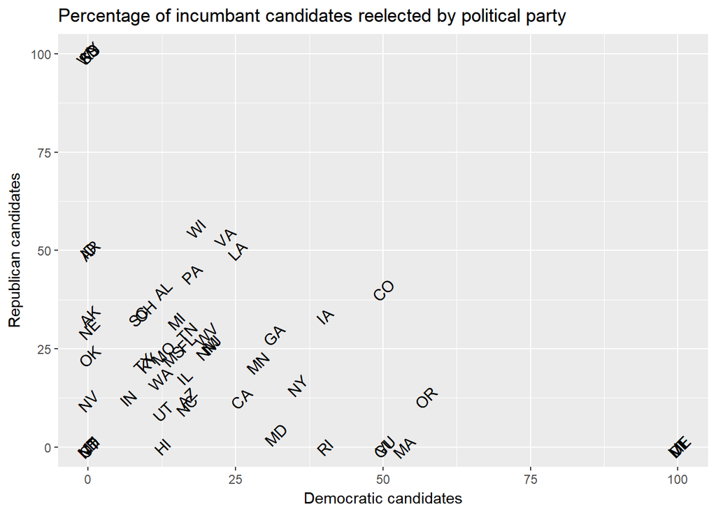

Figure 1: A comparison of the percentage of incumbent Democratic and Republican candidates running in states that got reelected

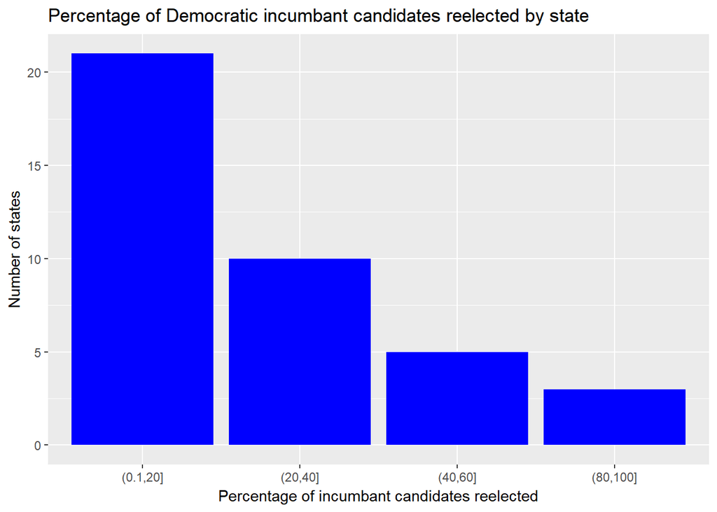

Figure 2: The distribution of percentages of Democratic incumbent candidates being reelected by state

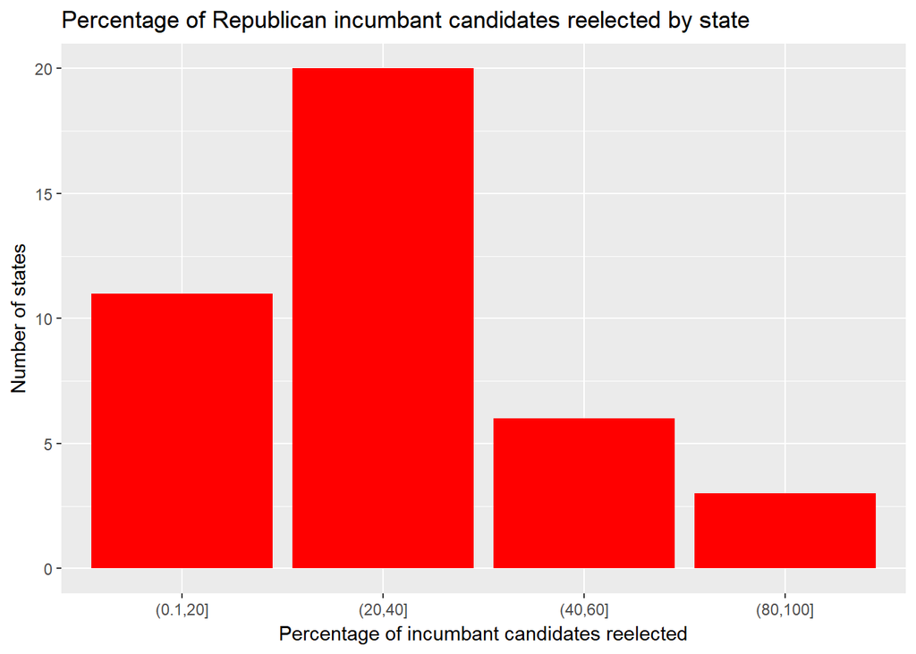

Figure 3: The distribution of percentages of Republican incumbent candidates being reelected by state